# RMED901 Group 3 final report

Anna-Kristina Fredheim Oma, Eric Holt, Maren Austevik Bø

2023-09-22

## Day 7 Visualization

### Are there any correlated measurements?

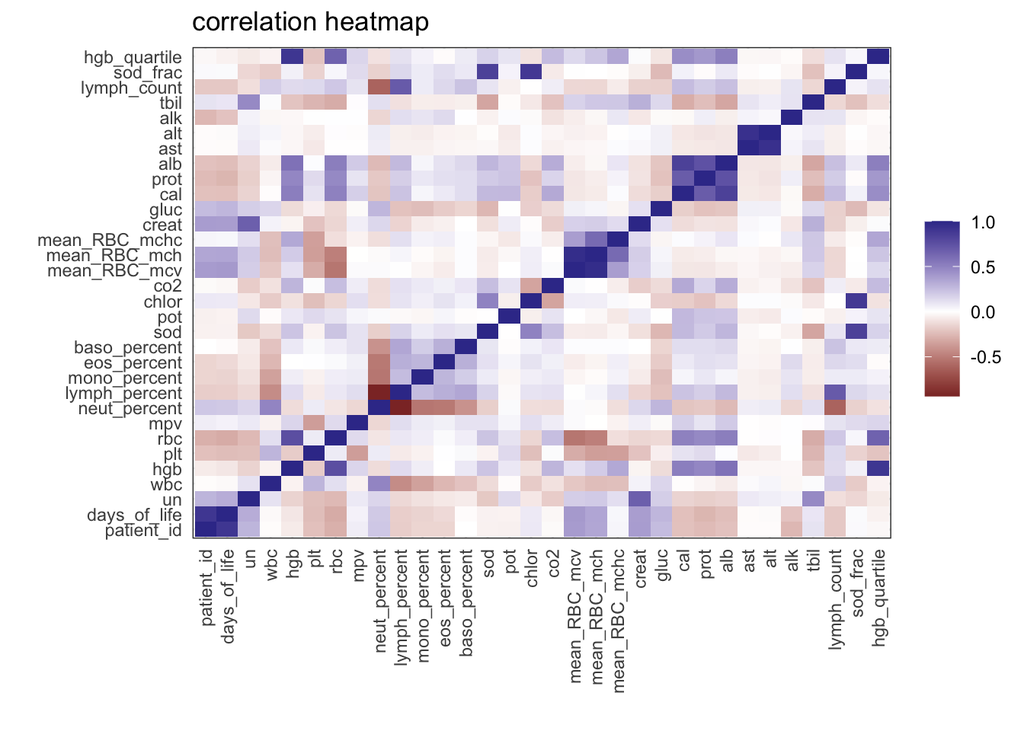

Some variables are positively or negatively correlated with each other. For example, the neutrophil proportion and white blood cell count are both negatively correlated with lymphocite, monocyte, eosinophil, and basophil proportions, while neutrophil and white blood cell count are positively correlated with each other, suggesting that a large portion of white blood cells are neutrophils.

### Does the sodium distribution depend on `gender`?

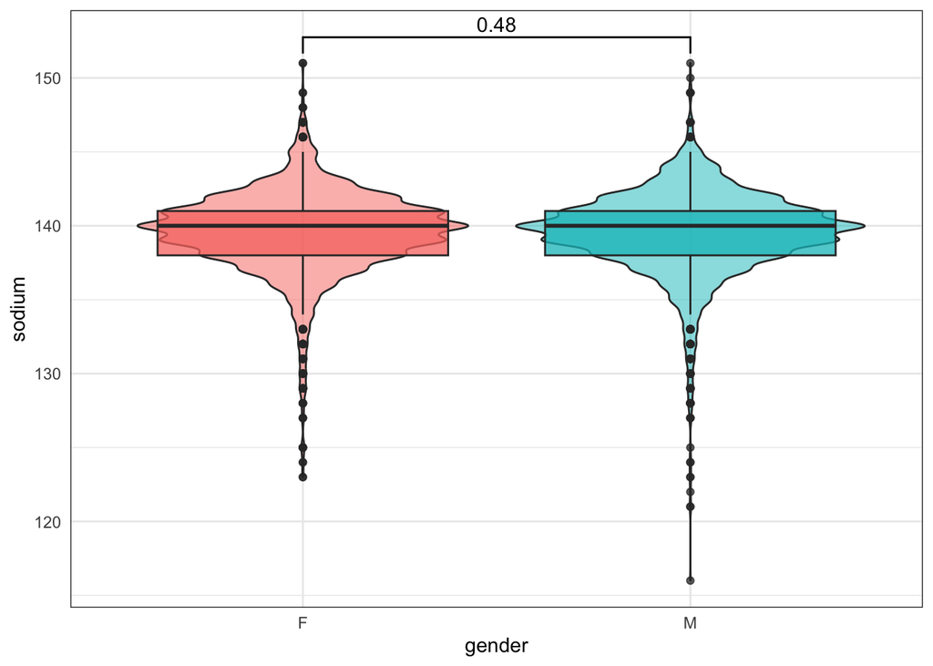

Sodium levels are distributed similarly between sexes. The difference is statistically insignificant (Welch two-sample $p=0.48$).

### Does the white blood cell count distribution depend on `pot`?

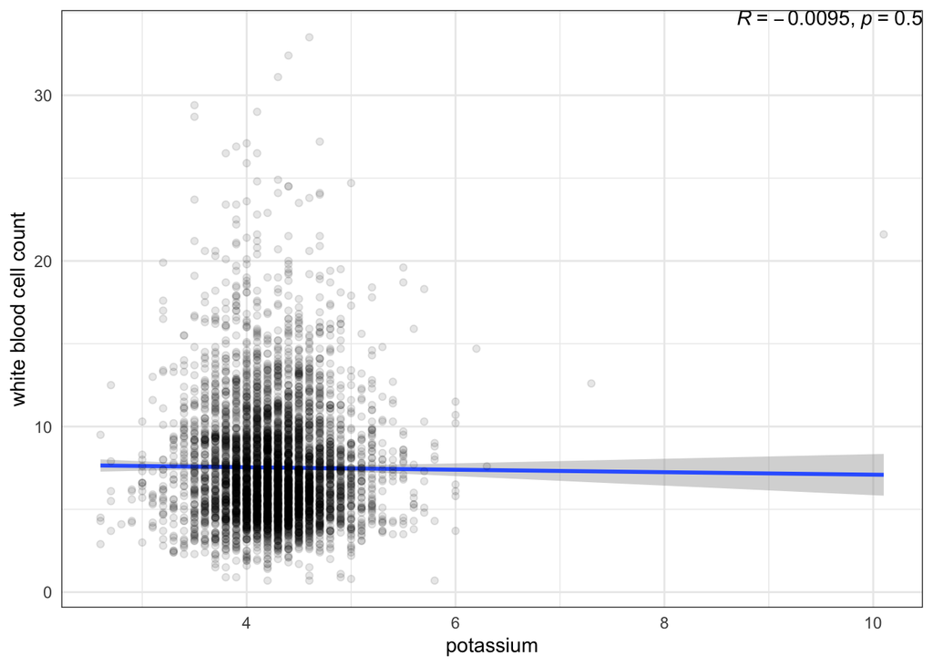

White blood cell count does not significantly (Pearson $R=-0.0095$, $p=0.5$) depend on the potassium level.

### Do albumin and protein have a linear relationship?

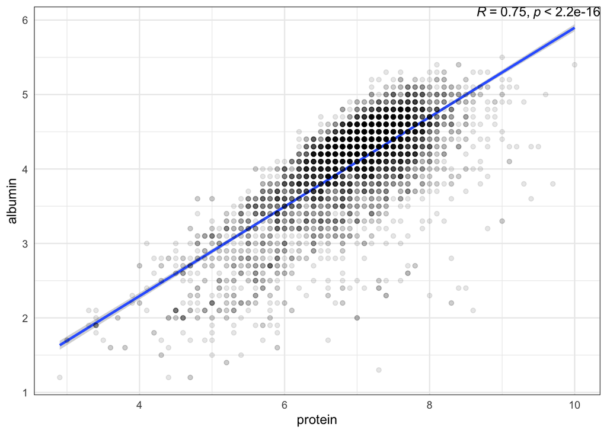

Albumin and protein levels have a linear relationship with each other. They are positively correlated (Pearson $R=0.75$, $p<2.2e-16$).

### Does remission of inflammation after Thiopurines for > 12 weeks change with percent of monocytes in WBC count?

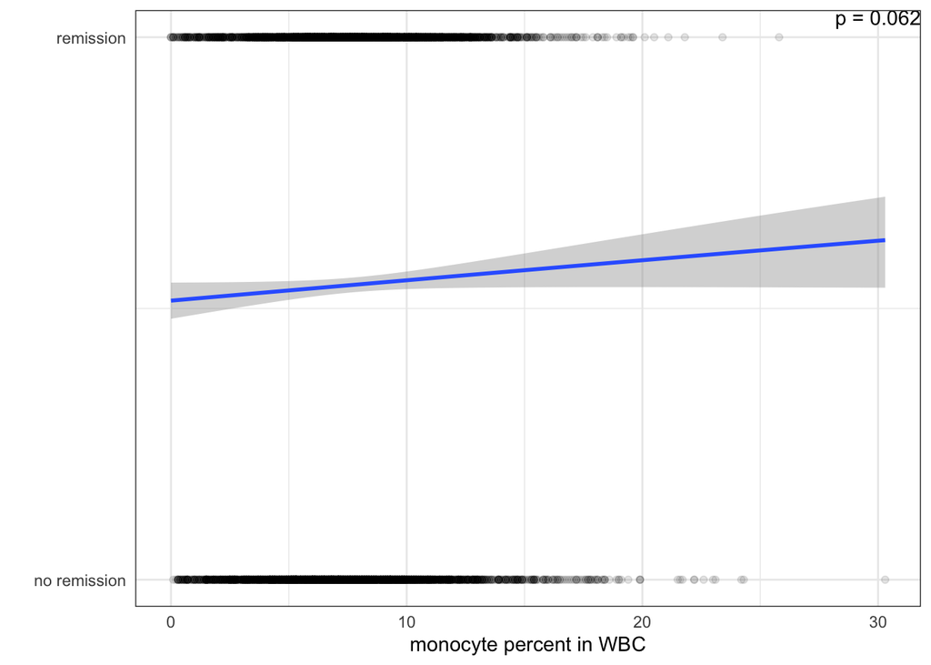

According to logistic regression, the monocyte proportion does not seem to predict remission very well ($p=0.062$).

## Day 8 Anasysis

### Does the remission depend on the gender?

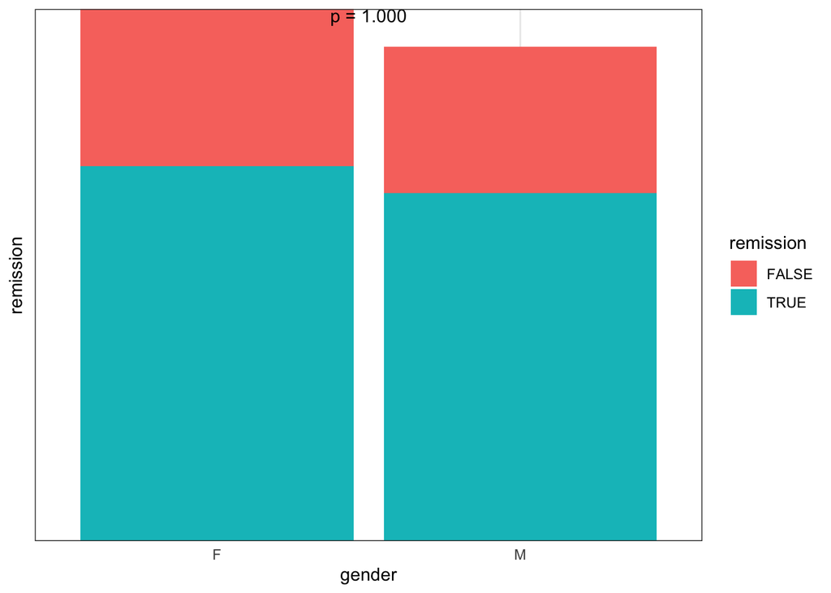

A $\chi^2$ test indicates no significant difference in remission rate between sexes ($p\approx1$).

### Does the remission depend on chloride?

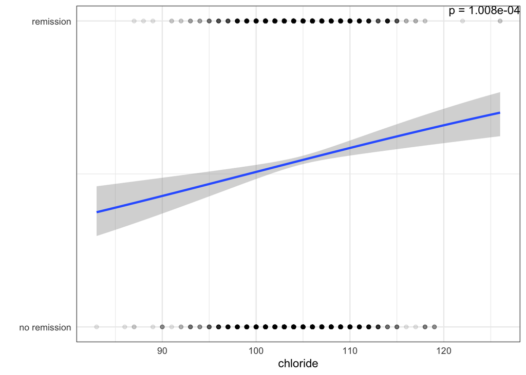

Logistic regression shows that higher chloride levels predict a higher probability of remission ($p=10^{-4}$).

### Is there an association between calcium and total bilirubin?

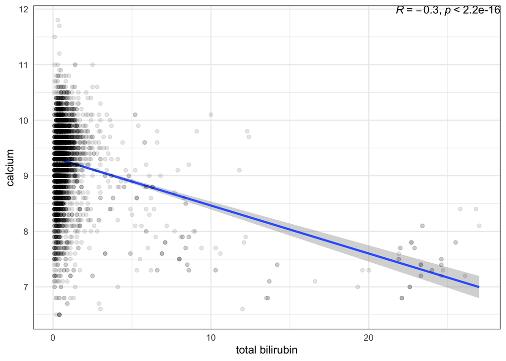

Linear regression shows a highly significant negative correlation (Pearson $R=-0.3$, $p<2.2e-16$) between the calcium and total bilirubin levels.

### According to the data, was there a difference of alanine transaminase between gender categories?

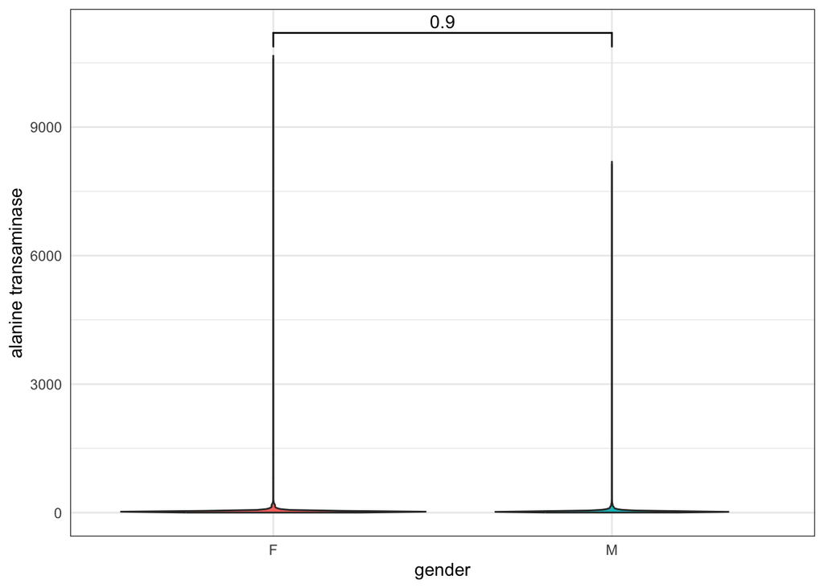

Alanine transaminase levels are distributed similarly between sexes. The difference is statistically insignificant (Welch two-sample $p=0.9$).